# Variable Selection in Longitudinal Data

### Cross covariance function

We checked the state-level correlation of grants allocation and graduation rate. In the state map, it shows that the majority states have a positive correlation between their grants receiption and the graduation rate.

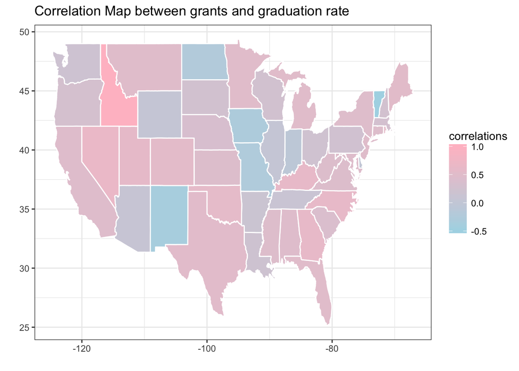

### Lasso in mixed model

Since we have longitudinal data, we may employ linear mixed effect model. With a large amount of variables compared with observations, a sparsity assumption can be made and L-1 penalization is added to the loss function to select variable. The model can be specified as following:
$$Y_i^T=\beta X_i+\alpha T+\epsilon_i$$
Where $\beta$ is fixed effect and $\alpha$ is random effect. In addition, we estimate the parameter by minimizing:
$$||Y-\beta X-\alpha T||_2^2+\lambda||\beta||_1$$

First we considered the ordinary lasso model, with cross validation to tune the penelization parameter.

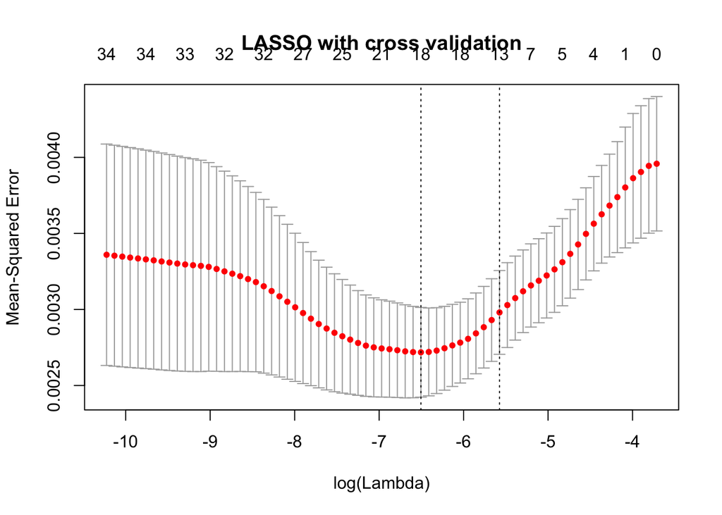

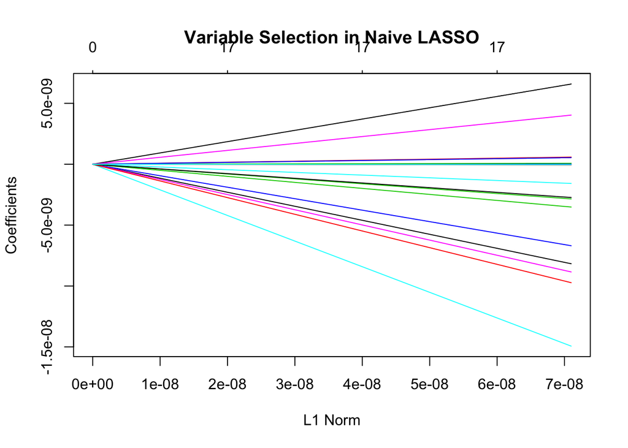

To further account for the random effect from time(year) on state-level graduation rate, we then consider the mixed-effect lasso model to choose the top 10 program grants that have the most significant coefficients deviate from 0.

```r
num = 0
i=1000
important1 <- NULL
while(num<11){
  a = which(res1[i,]!=0)
  if(length(important1)!=length(a)){
    add <- setdiff(names(a),important1)
    important1 <- c(important1,add)
    num <- length(important1)
  }
  i = i-1
}
important1[-1]
```

```
##  [1] "`84.060`" "`84.295`" "`84.351`" "`84.356`" "`84.358`" "`84.360`"
##  [7] "`84.369`" "`84.367`" "`84.010`" "`84.184`"
```

It shows that program “84.060”,“84.184”,“84,295”,“84.351”,“84.356”,“84.358”,“84.360”,“84.367” and “84.369” have more effect. The top 10 program grants with significant impact on state-level graduation rate are:

84.060: Indian Education_Grants to Local Educational Agencies 84.295: Ready-To-Learn Television 84.351: Arts in Education 84.356: Alaska Native Educational Program 84.358: Rural Education 84.360: High School Graduation Initiative 84.369: Grants for State Assessments and Related Activities 84.367: Improving Teacher Quality State Grants 84.010: Title I Grants to Local Educational Agency 84.184: Safe and Drug-free Schools and Communities_National Programs

### Regression Tree with Random Effect

In addition, we also employ random forest to see which variable are more important.

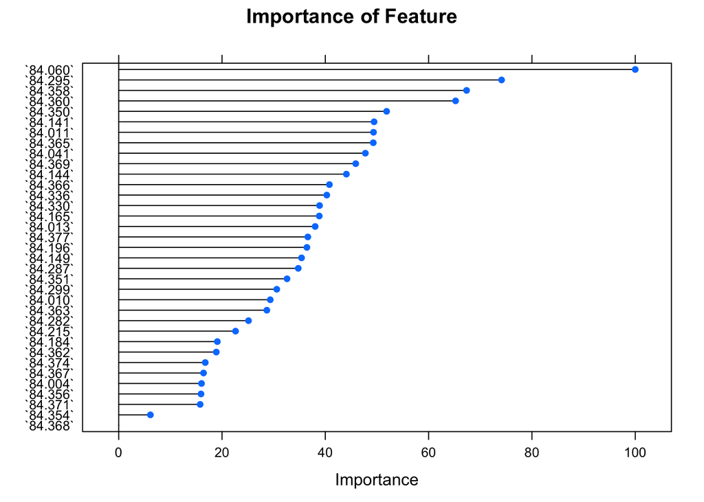

As we can conclude from the random forest model and lass/Mixed-effect lasso model, there is some overlap of the “significant” grants on lifting the state-level graduation rates.

Some further analysis may include: Case study for states that shows negative correlation on graduation rate and grants receipient; Analysis on “important” program grants.